# Exploración visual y ajuste de un modelo predictivo con corrplot y visreg

Ana Buendía Ruiz-Azuaga

Lucas Fehlau Arbulu

Andrés Millán Muñoz

Paula Villanueva Núñez

17 de June de 2022

En este trabajo estudiaremos de forma visual el conjunto de datos `Seatbelts`, el cual recoge información sobre los accidentes de tráfico mortales en Gran Bretaña comprendidos entre los años 1969 y 1984. Estos datos resultan relevantes ya que la ley relacionada con la obligatoriedad de los cinturones se introdujo el 31 de enero de 1983.

Las variables de este conjunto de datos son:

https://stat.ethz.ch/R-manual/R-devel/library/datasets/html/UKDriverDeaths.html

- **DriversKilled**: el número de conductores fallecidos.
- **drivers**: conductores en un cierto año.
- **front**: número de copilotos fallecidos o gravemente heridos.
- **rear**: número de pasajeros en los asientos traseros fallecidos o gravemente heridos.
- **kms**: distancia recorrida en total por todos los conductores.
- **PetrolPrice**: precio del petróleo.
- **VanKilled**: número de conductores de furgonetas fallecidos.
- **law**: si estaba en efecto la ley de tránsito en ese mes.

Comprobaremos las correlaciones entre sus variables y construiremos un modelo predictivo, observando gráficamente la efectividad de este.

# Análisis de correlaciones (corrplot)

## Introducción

El análisis de correlaciones puede llevarse a cabo de forma teórica o visual. Nosotros nos vamos a centrar en realizar este análisis de forma visual usando herramientas de análisis visual exploratorio a partir de la matriz de correlaciones. De esta forma, podemos ver de forma intuitiva las diferentes correlaciones, ayudándonos así a detectar patrones ocultos en los datos.

Para ello, primero necesitamos instalar los paquetes necesarios para el análisis visual de las correlaciones. El paquete `corrplot` puede instalarse de la siguiente manera:

```r
# install.packages("corrplot")
library(corrplot)
```

Usaremos el dataframe `Seatbelts` para el análisis. Afortunadamente, no tiene datos incompletos.

```r
SB <- ts(Seatbelts, start = 1969, frequency = 12)
summary(SB)
```

```
##  DriversKilled      drivers         front             rear
##  Min.   : 60.0   Min.   :1057   Min.   : 426.0   Min.   :224.0
##  1st Qu.:104.8   1st Qu.:1462   1st Qu.: 715.5   1st Qu.:344.8
##  Median :118.5   Median :1631   Median : 828.5   Median :401.5
##  Mean   :122.8   Mean   :1670   Mean   : 837.2   Mean   :401.2
##  3rd Qu.:138.0   3rd Qu.:1851   3rd Qu.: 950.8   3rd Qu.:456.2
##  Max.   :198.0   Max.   :2654   Max.   :1299.0   Max.   :646.0
##       kms         PetrolPrice        VanKilled           law
##  Min.   : 7685   Min.   :0.08118   Min.   : 2.000   Min.   :0.0000
##  1st Qu.:12685   1st Qu.:0.09258   1st Qu.: 6.000   1st Qu.:0.0000
##  Median :14987   Median :0.10448   Median : 8.000   Median :0.0000
##  Mean   :14994   Mean   :0.10362   Mean   : 9.057   Mean   :0.1198
##  3rd Qu.:17203   3rd Qu.:0.11406   3rd Qu.:12.000   3rd Qu.:0.0000
##  Max.   :21626   Max.   :0.13303   Max.   :17.000   Max.   :1.0000
```

La función `cor()`, incluida por defecto en R, calcula la matriz de correlaciones utilizando el coeficiente de correlación de Pearson.

```r
corSB <- cor(SB)
corSB
```

```
##               DriversKilled    drivers      front        rear        kms
## DriversKilled     1.0000000  0.8888264  0.7067596  0.35335102 -0.3211016
## drivers           0.8888264  1.0000000  0.8084114  0.34366850 -0.4447631
## front             0.7067596  0.8084114  1.0000000  0.62022476 -0.3573823
## rear              0.3533510  0.3436685  0.6202248  1.00000000  0.3330069
## kms              -0.3211016 -0.4447631 -0.3573823  0.33300689  1.0000000
## PetrolPrice      -0.3866061 -0.4576675 -0.5392394 -0.13262721  0.3839004
## VanKilled         0.4070412  0.4853995  0.4724207  0.12175808 -0.4980356
## law              -0.3285051 -0.4452269 -0.5624455  0.02906753  0.4905494
##               PetrolPrice  VanKilled         law
## DriversKilled  -0.3866061  0.4070412 -0.32850510
## drivers        -0.4576675  0.4853995 -0.44522689
## front          -0.5392394  0.4724207 -0.56244554
## rear           -0.1326272  0.1217581  0.02906753
## kms             0.3839004 -0.4980356  0.49054938
## PetrolPrice     1.0000000 -0.2885584  0.39069323
## VanKilled      -0.2885584  1.0000000 -0.39494121
## law             0.3906932 -0.3949412  1.00000000
```

Esta matriz se entiende mejor si utilizamos el gráfico correcto. Aquí es donde entra en juego el paquete `corrplot`. Por defecto, su salida es la siguiente:

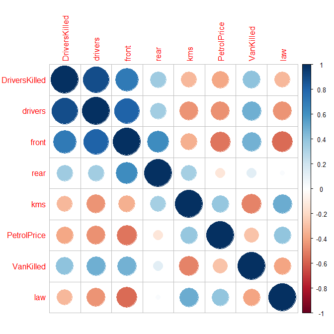

```r
corrplot(corSB)
```

Este gráfico muestra las correlaciones entre cada una de las variables de dos formas simultáneamente:

- **Mediante el tamaño de los puntos**: a mayor tamaño del círculo, mayor valor absoluto de correlación.
- **Mediante el color de los puntos**: los puntos toman un color según la correlación que tengan las variables, indicando el rojo que estas están negativamente correlacionadas y el azul que lo están positivamente.

Podemos visualizar la misma matriz de correlaciones mostrando los números en lugar de los círculos anteriores (la opción predeterminada es `method='circle'`).

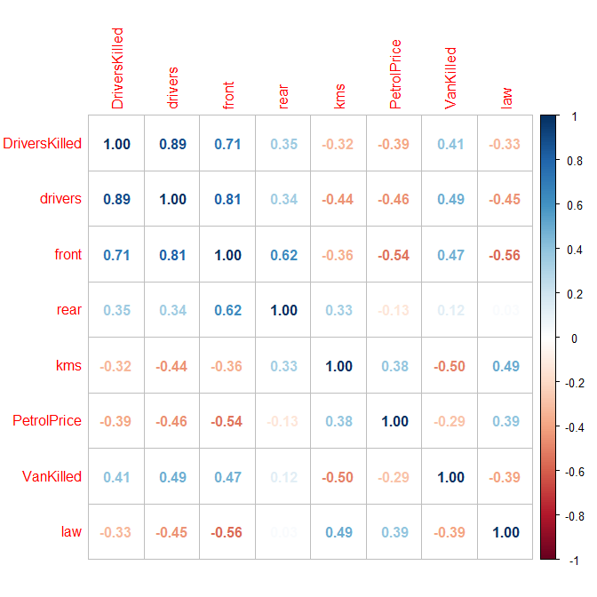

```r
corrplot(corSB, method = "number")
```

También puede mostrarse con cuadrados en lugar de círculos, de forma que el gráfico se asemeja a un *heatmap*:

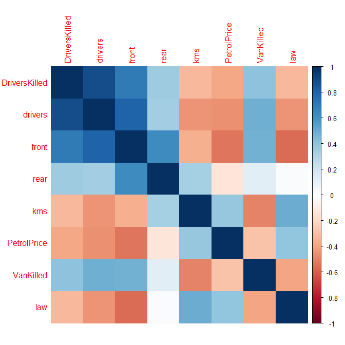

```r
corrplot(corSB, method = "color")
```

Otras opciones para el valor de `method` son `square`, `ellipse`, `shade` o `pie`, las cuáles podremos visualizar en la sección siguiente.

## Cambiando el orden de las variables

Podemos cambiar el orden de las variables en la representación con las siguientes opciones:

- `AOE`: sigue el orden angular de los vectores propios.
- `FPC`: Ordena según la componente principal.
- `hclust`: Ordena basándose en la jerarquía de clusters.
- `alphabet`: Orden alfabético.

[figure not shown]

```r
corrplot(corSB, method = "shade", order = "AOE")
```

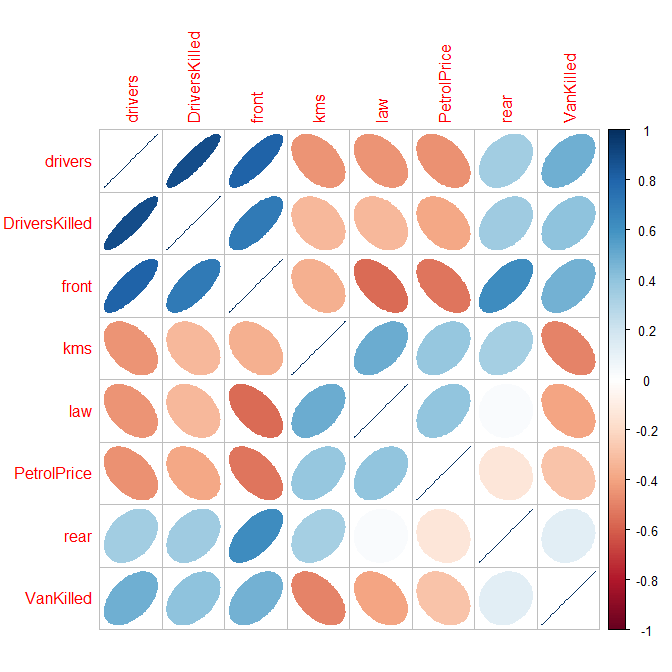

```r
corrplot(corSB, method = "ellipse", order = "alphabet")
```

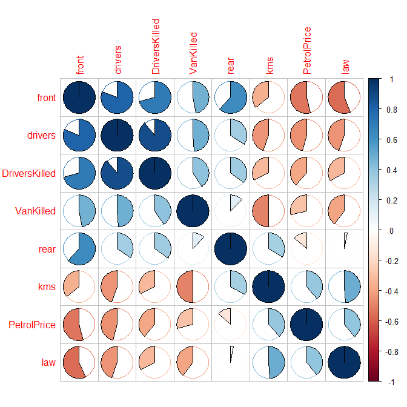

```r
corrplot(corSB, method = "pie", order = "FPC")
```

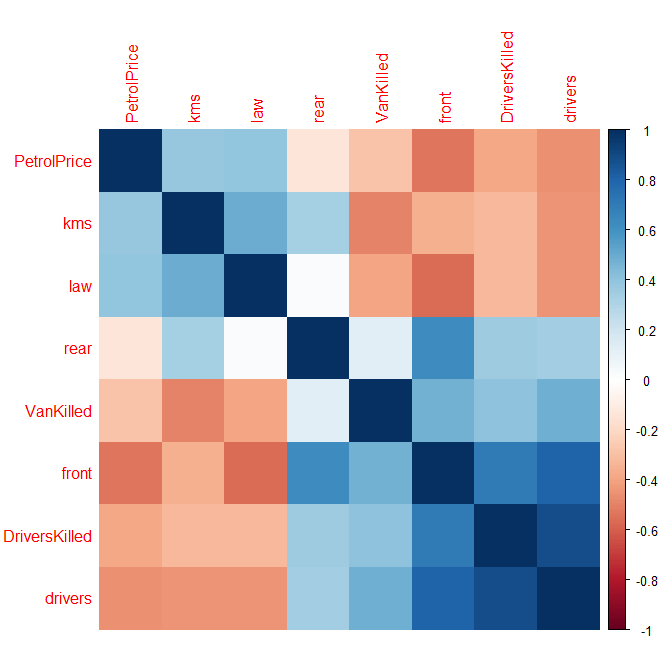

```r
corrplot(corSB, method = "color", order = "hclust")
```

## Diagonales y matrices triangulares

La diagonal principal de la matriz de correlaciones expresa la correlación de una variable consigo misma, que siempre vale 1, y por tanto no aporta ninguna información relevante. Podemos desactivar la representación de esta diagonal como sigue:

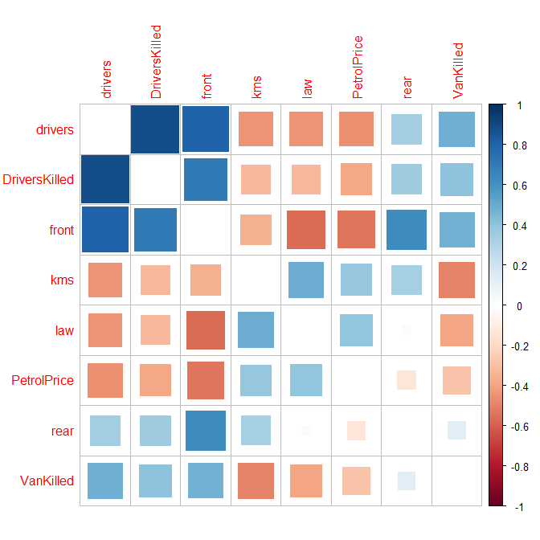

```r
corrplot(corSB, method = "square", order = "alphabet", diag = FALSE)
```

Como la matriz de correlaciones es simétrica, podemos mostrar únicamente la triangular superior o la inferior.

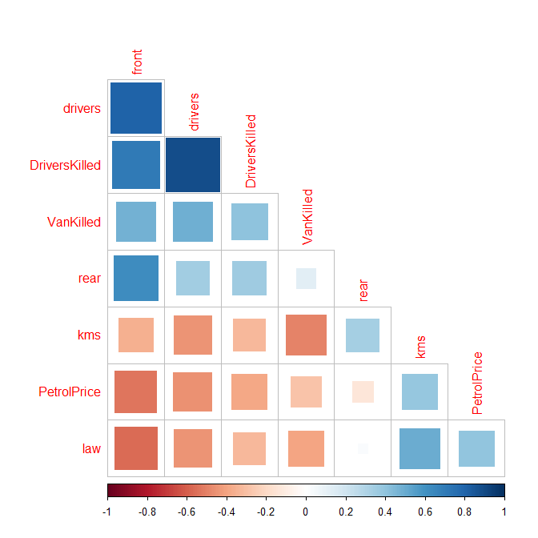

```r
corrplot(corSB, method = "square", order = "FPC", type = "lower", diag = FALSE)
```

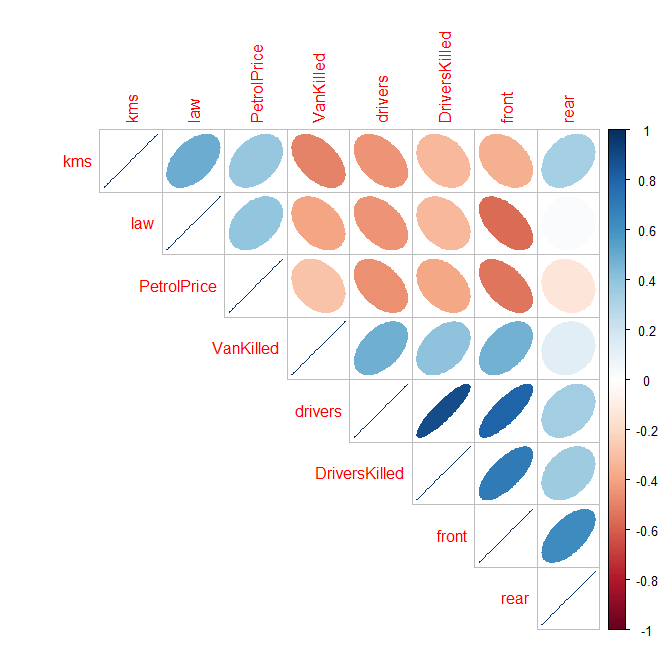

```r
corrplot(corSB, method = "ellipse", order = "AOE", type = "upper")
```

Para mostrar más información en una sola gráfica, podemos usar la función `corrplot.mixed`, que representa la mitad superior de la matriz de correlaciones de una forma (por defecto con círculos) y la inferior de otra (por defecto con números).

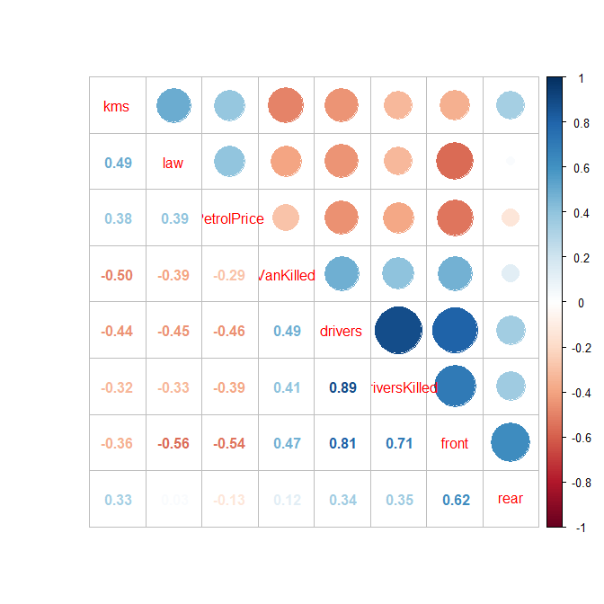

```r
corrplot.mixed(corSB, order = "AOE")
```

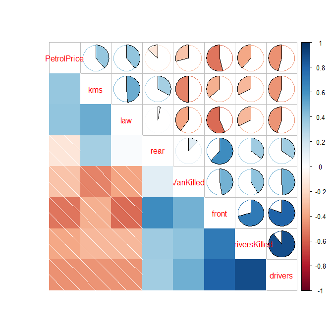

```r
corrplot.mixed(corSB, lower = "shade", upper = "pie", order = "hclust")
```

## Agrupando por clustering

Si estamos usando `hclust` como método de ordenación podemos añadir rectángulos en el gráfico de la matriz de correlación según el resultado del agrupamiento por clustering.

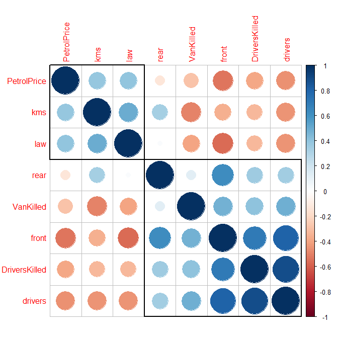

```r
corrplot(corSB, order = "hclust", addrect = 2)
```

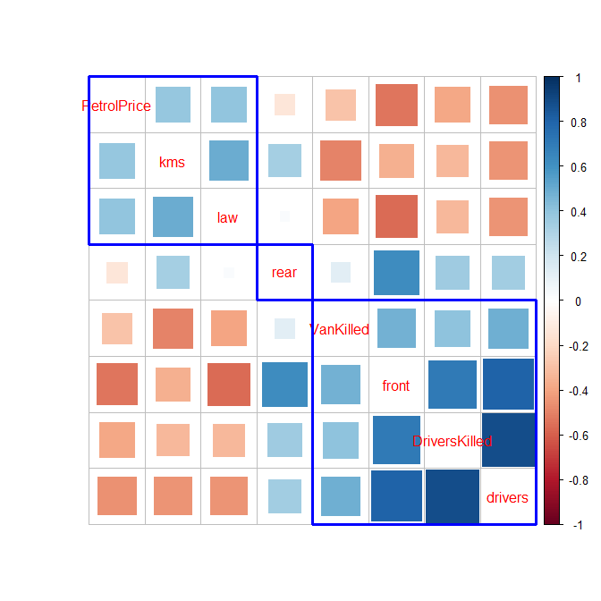

```r
corrplot(
    corSB, method = "square", diag = FALSE, order = "hclust",
    addrect = 3, rect.col = "blue", rect.lwd = 3, tl.pos = "d"
)
```

## Personalizando los colores

Podemos modificar los colores que se usan en las gráficas que vienen por defecto. Esto se puede hacer con el argumento `col`, al que le pasaremos los colores que queremos usar. Por ejemplo, podemos usar colores secuenciales, tales como `YlGn`, `OrRd`, `YlOrRd`, `YlOrBr`, `Blues`, `Reds`, `Greens`, `Purples`, etc; o colores divergentes, tales como `RdBu`, `BrBG`, `PiYG`, `PRGn`, `PuOr` o `RdYlBu`. Los colores generados pueden ser obtenidos mediante las funciones `COL1` o `COL2`, respectivamente. El primero se encarga de interpolar entre los dos extremos, mientras que el segundo genera paletas divergentes.

En la siguiente ejecución se muestra el gráfico de las correlaciones entre las variables usando tonos morados:

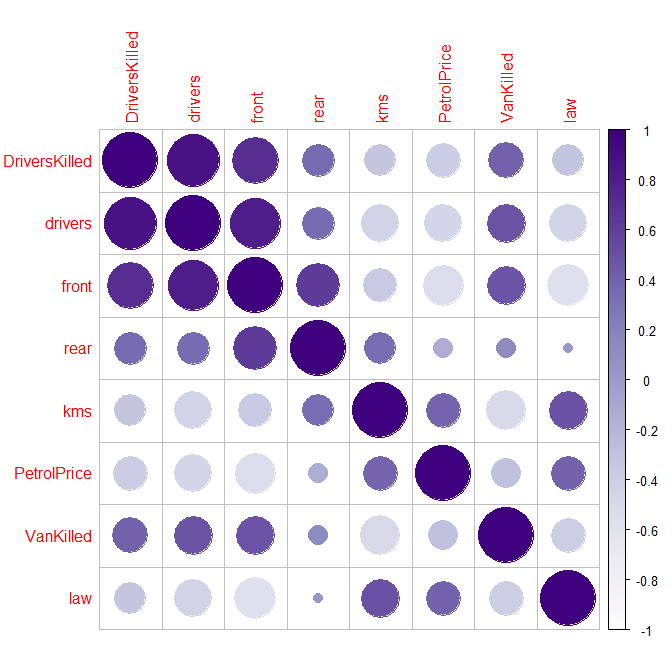

```r
corrplot(corSB, col = COL1("Purples"))
```

Si queremos que el gráfico tenga colores entre el tono naranja y el tono verde, ejecutamos lo siguiente:

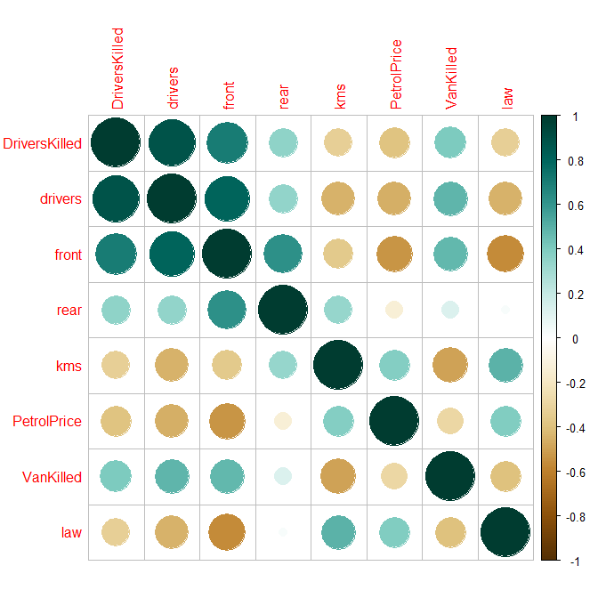

```r
corrplot(corSB, col = COL2("BrBG"))
```

También podemos cambiar el color del fondo con el argumento `bg`.

## Visualizar una matriz distinta a la de correlación

Podemos visualizar una matriz que no es de correlaciones estableciendo el argumento `is.corr` como `FALSE`:

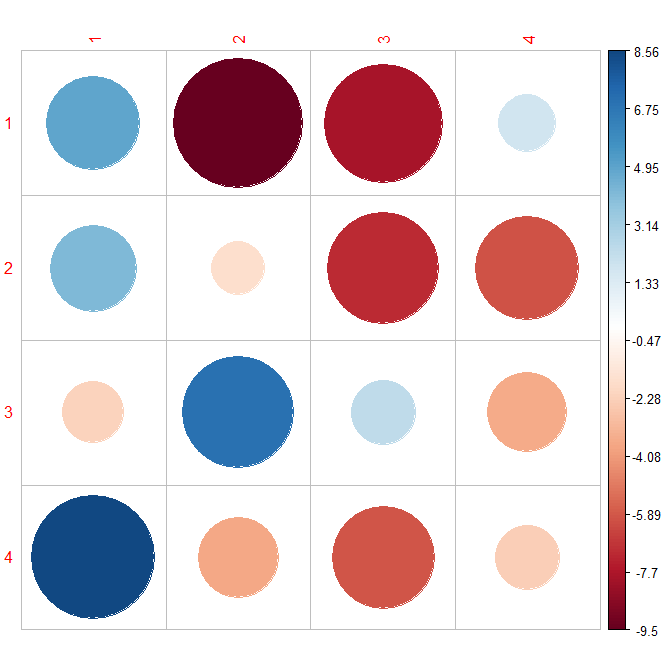

```r
corrplot(
    matrix(runif(16, min = -10, max = 10), 4, 4),
    is.corr = FALSE
)
```

Observemos que los límites del rango de colores cambian.

## Mostrando niveles de significación e intervalos de confianza

La función `corrplot()` puede visualizar los p-valores y el intervalo de confianza de la matriz de correlaciones. Por ejemplo, aquí generamos intervalos de confianza para un nivel de confianza $\alpha = 0.95$, y visualizamos qué relaciones son estadísticamente significantes al nivel $1 - \alpha = 0.05$:

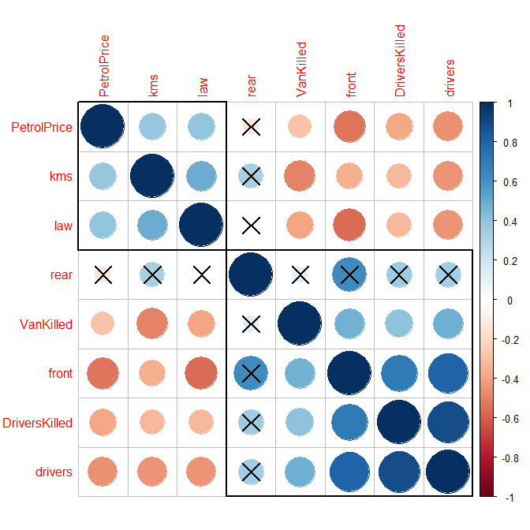

```r
test <- cor.mtest(corSB, conf.level = 0.95)
corrplot(corSB, p.mat = test$p, sig.level = 0.05, order = "hclust", addrect = 2)
```

Una opción interesante es dejar en blanco las entradas para las que falla el test, y añadimos los coeficientes para los que sí se acepta:

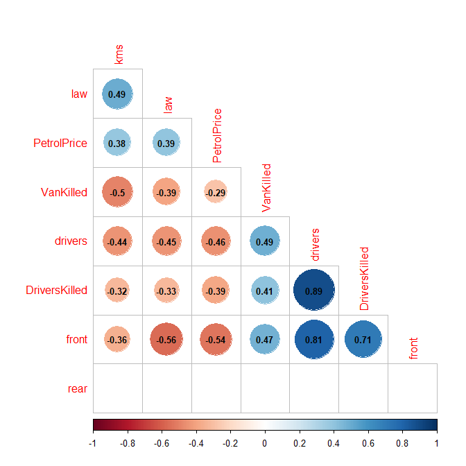

```r
corrplot(
    corSB, p.mat = test$p, method = "circle", type = "lower", insig = "blank",
    addCoef.col = "black", number.cex = 0.8, order = "AOE", diag = FALSE
)
```

Se pueden visualizar los intervalos de confianza explícitamente mediante diagramas de cajas de la siguiente manera:

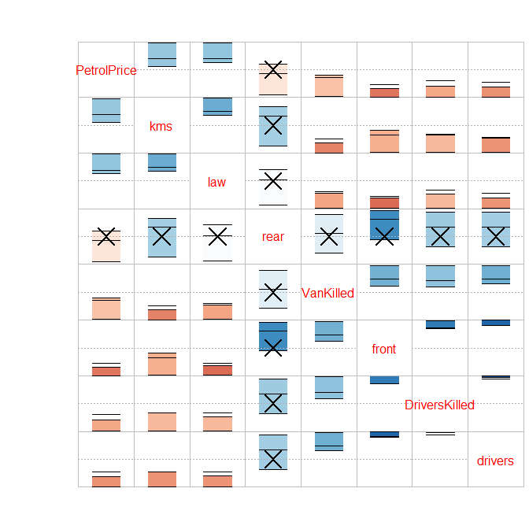

```r
corrplot(
    corSB, p.mat = test$p, lowCI = test$lowCI, uppCI = test$uppCI,
    order = "hclust", tl.pos = "d", rect.col = "navy", plotC = "rect", cl.pos = "n"
)
```

# Visualización de un modelo de regresión (visreg)

En esta sección realizaremos la construcción de un modelo de regresión y, usando el paquete `visreg`, visualizaremos el ajuste de dicho modelo. Este paquete permite resolver el problema de saber cuánta relación existe entre algunas variables de un conjunto de datos.

Para ello, primero necesitamos instalar y cargar dicho paquete con las siguientes órdenes:

```r
# install.packages("visreg")
library(visreg)
```

Antes de analizar, observamos los datos en función del tiempo.

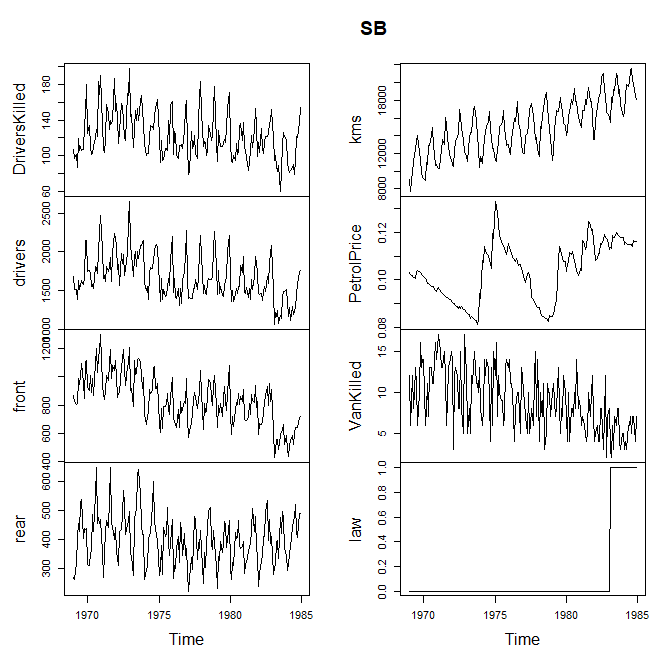

```r
plot(SB)
```

Podemos ajustar un modelo lineal que permita describir el número de conductores fallecidos en función del número de conductores con la función `lm`:

```r
fit <- lm(DriversKilled ~ drivers, data = SB)
```

Con la función `visreg()` podemos visualizar el modelo:

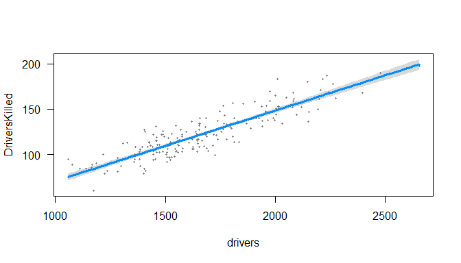

```r
visreg(fit)
```

En el gráfico anterior observamos la relación lineal estimada por el modelo y una banda de confianza sobre esa estimación.

También podemos hacer diagramas con varias variables explicativas, como por ejemplo podemos visualizar el modelo que describe cuántos conductores han fallecido en función del número total de conductores y la distancia recorrida:

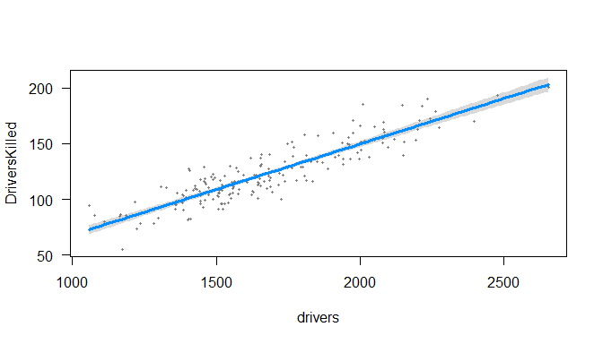

```r
fit1 <- lm(DriversKilled ~ drivers + kms, data = SB)
visreg(fit1, xvar = "drivers")
```

En particular, observamos cierta correlación entre la distancia total, el número de conductores de camiones fallecidos y el de vehículos fallecidos:

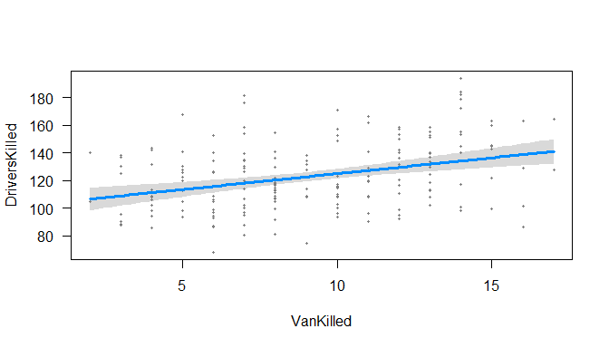

```r
fitVan <- lm(DriversKilled ~ kms + VanKilled, data = SB)
visreg(fitVan, xvar = "VanKilled")
```

Incluyendo en el modelo el número de conductores, obtenemos:

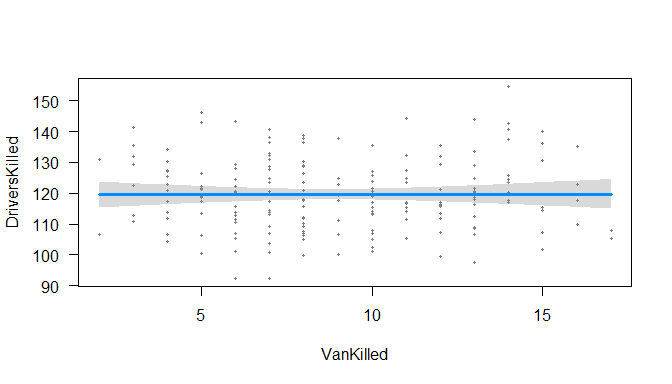

```r
fitVan <- lm(DriversKilled ~ drivers + kms + VanKilled, data = SB)
visreg(fitVan, xvar = "VanKilled")
```

Otra observación curiosa es que, en todo el conjunto de datos, el número de conductores y de kilómetros recorridos no están positivamente correlacionados:

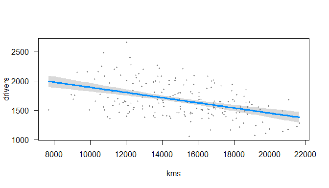

```r
fitdriversporkms <- lm(drivers ~ kms, data = SB)
visreg(fitdriversporkms)
```

Esto se debe a que los datos corresponden a una serie temporal estacional, y por tanto, un análisis basado en regresión lineal no tiene mucho sentido.

También podemos dividir las gráficas según los valores de un factor:

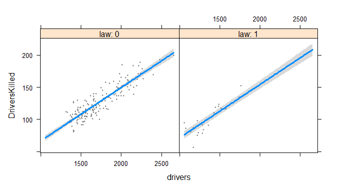

```r
fitlaw <- lm(DriversKilled ~ drivers + kms + law, data = SB)
visreg(fitlaw, xvar = "drivers", by = "law")
```

En realidad, puede ser cualquier variable. Si es continua, se puede indicar cómo se dividen por el argumento `breaks`.

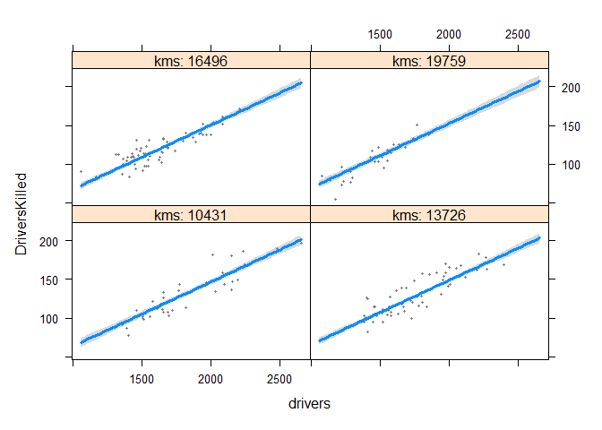

```r
visreg(fitlaw, xvar = "drivers", by = "kms", breaks = 4)
```

Otra opción interesante es superponer los gráficos anteriores en una sola gráfica:

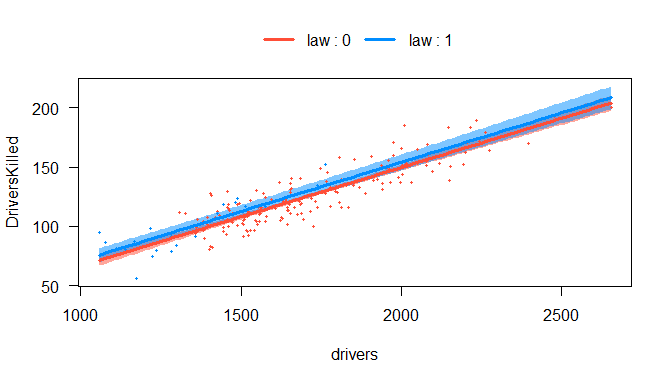

```r
visreg(fitlaw, xvar = "drivers", by = "law", overlay = TRUE)
```

También funciona para ajustes no lineales:

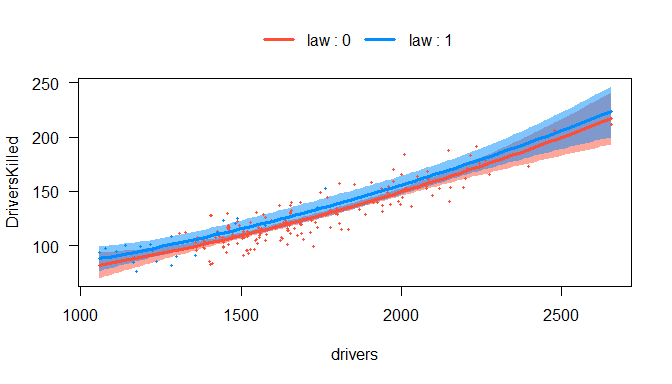

```r
fitpoly <- lm(DriversKilled ~ poly(kms, 2) * poly(drivers, 2) + law, data = SB)
visreg(fitpoly, xvar = "drivers", by = "law", overlay = TRUE)
```

En modelos más complicados se pueden hacer gráficas de contorno o contour:

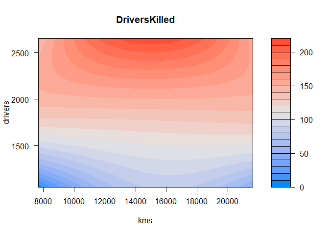

```r
visreg2d(fitpoly, "kms", "drivers")
```

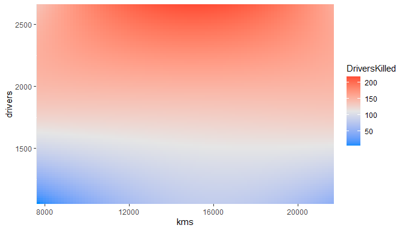

```r
visreg2d(fitpoly, "kms", "drivers", plot.type = "gg")
```

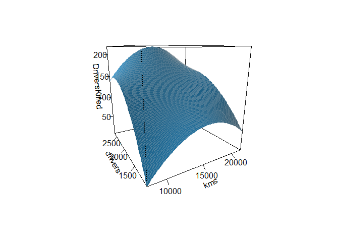

```r
visreg2d(fitpoly, "kms", "drivers", plot.type = "persp")
```